# ProjectUpdatefinal

READING THE CSV FILE EXTRACTED FROM NOAA (National Centerers for enviromental information)

```python
import pandas as pd
weather = pd.read_csv("Weather.csv" , index_col="DATE")
weather
```

| DATE | STATION | NAME | ACMH | ACSH | AWND | FMTM | PGTM | PRCP | SNOW | SNWD | ... | WT13 | WT14 | WT15 | WT16 | WT17 | WT18 | WT19 | WT21 | WT22 | WV01 |
| --- | --- | --- | --- | --- | --- | --- | --- | --- | --- | --- | --- | --- | --- | --- | --- | --- | --- | --- | --- | --- | --- |
| 1970-01-01 | USW00094789 | JFK INTERNATIONAL AIRPORT, NY US | 80.0 | 90.0 | NaN | NaN | NaN | 0.00 | 0.0 | 0.0 | ... | NaN | NaN | NaN | NaN | NaN | NaN | NaN | NaN | NaN | NaN |
| 1970-01-02 | USW00094789 | JFK INTERNATIONAL AIRPORT, NY US | 30.0 | 20.0 | NaN | NaN | NaN | 0.00 | 0.0 | 0.0 | ... | NaN | NaN | NaN | NaN | NaN | NaN | NaN | NaN | NaN | NaN |
| 1970-01-03 | USW00094789 | JFK INTERNATIONAL AIRPORT, NY US | 80.0 | 100.0 | NaN | NaN | NaN | 0.02 | 0.0 | 0.0 | ... | NaN | NaN | NaN | 1.0 | NaN | 1.0 | NaN | NaN | NaN | NaN |
| 1970-01-04 | USW00094789 | JFK INTERNATIONAL AIRPORT, NY US | 10.0 | 20.0 | NaN | NaN | NaN | 0.00 | 0.0 | 0.0 | ... | NaN | NaN | NaN | NaN | NaN | 1.0 | NaN | NaN | NaN | NaN |
| 1970-01-05 | USW00094789 | JFK INTERNATIONAL AIRPORT, NY US | 30.0 | 10.0 | NaN | NaN | NaN | 0.00 | 0.0 | 0.0 | ... | NaN | NaN | NaN | NaN | NaN | NaN | NaN | NaN | NaN | NaN |
| ... | ... | ... | ... | ... | ... | ... | ... | ... | ... | ... | ... | ... | ... | ... | ... | ... | ... | ... | ... | ... | ... |
| 2023-11-06 | USW00094789 | JFK INTERNATIONAL AIRPORT, NY US | NaN | NaN | 8.05 | NaN | NaN | 0.00 | 0.0 | 0.0 | ... | NaN | NaN | NaN | NaN | NaN | NaN | NaN | NaN | NaN | NaN |
| 2023-11-07 | USW00094789 | JFK INTERNATIONAL AIRPORT, NY US | NaN | NaN | 10.96 | NaN | NaN | 0.01 | 0.0 | 0.0 | ... | NaN | NaN | NaN | NaN | NaN | NaN | NaN | NaN | NaN | NaN |
| 2023-11-08 | USW00094789 | JFK INTERNATIONAL AIRPORT, NY US | NaN | NaN | 12.30 | NaN | NaN | 0.00 | 0.0 | 0.0 | ... | NaN | NaN | NaN | NaN | NaN | NaN | NaN | NaN | NaN | NaN |
| 2023-11-09 | USW00094789 | JFK INTERNATIONAL AIRPORT, NY US | NaN | NaN | 6.71 | NaN | 551.0 | 0.00 | 0.0 | 0.0 | ... | NaN | NaN | NaN | NaN | NaN | NaN | NaN | NaN | NaN | NaN |
| 2023-11-10 | USW00094789 | JFK INTERNATIONAL AIRPORT, NY US | NaN | NaN | NaN | NaN | NaN | 0.00 | 0.0 | 0.0 | ... | NaN | NaN | NaN | NaN | NaN | NaN | NaN | NaN | NaN | NaN |

19672 rows × 45 columns

Finding the null values in our data set

```python
weather.apply(pd.isnull).sum() #this will give us the number of null values in the data set
```

```
STATION        0
NAME           0
ACMH       10057
ACSH       10056
AWND        5116
FMTM        9548
PGTM        7403
PRCP           0
SNOW           0
SNWD           2
TAVG       13123
TMAX           0
TMIN           0
TSUN       19641
WDF1       10061
WDF2        9618
WDF5        9701
WDFG       14551
WDFM       19671
WESD       13601
WSF1       10058
WSF2        9618
WSF5        9702
WSFG       12209
WSFM       19671
WT01       12393
WT02       18395
WT03       18351
WT04       19329
WT05       19308
WT06       19491
WT07       19564
WT08       15727
WT09       19532
WT11       19658
WT13       17487
WT14       18785
WT15       19630
WT16       13095
WT17       19612
WT18       18505
WT19       19671
WT21       19667
WT22       19623
WV01       19671
dtype: int64
```

Finding the percentage of null values in our dataset so that we can extract all the data with lower percentage of null values to maintain data quality , reduce biasness , better model performance.

```python
null_percentage=weather.apply(pd.isnull).sum()/weather.shape[0]
null_percentage #showing the percentage of null values in each column
```

```
STATION    0.000000
NAME       0.000000
ACMH       0.511234
ACSH       0.511183
AWND       0.260065
FMTM       0.485360
PGTM       0.376322
PRCP       0.000000
SNOW       0.000000
SNWD       0.000102
TAVG       0.667090
TMAX       0.000000
TMIN       0.000000
TSUN       0.998424
WDF1       0.511438
WDF2       0.488918
WDF5       0.493137
WDFG       0.739681
WDFM       0.999949
WESD       0.691389
WSF1       0.511285
WSF2       0.488918
WSF5       0.493188
WSFG       0.620628
WSFM       0.999949
WT01       0.629982
WT02       0.935085
WT03       0.932849
WT04       0.982564
WT05       0.981497
WT06       0.990799
WT07       0.994510
WT08       0.799461
WT09       0.992883
WT11       0.999288
WT13       0.888928
WT14       0.954911
WT15       0.997865
WT16       0.665667
WT17       0.996950
WT18       0.940677
WT19       0.999949
WT21       0.999746
WT22       0.997509
WV01       0.999949
dtype: float64
```

extracting the data wtih NULL values lower than 5%

```python
Data_with_lower_null_percentage = weather.columns[null_percentage < 0.05]
Data_with_lower_null_percentage
```

```
Index(['STATION', 'NAME', 'PRCP', 'SNOW', 'SNWD', 'TMAX', 'TMIN'], dtype='object')
```

```python
weather = weather[Data_with_lower_null_percentage].copy()
weather.columns=weather.columns.str.lower()
weather
```

| DATE | station | name | prcp | snow | snwd | tmax | tmin |
| --- | --- | --- | --- | --- | --- | --- | --- |
| 1970-01-01 | USW00094789 | JFK INTERNATIONAL AIRPORT, NY US | 0.00 | 0.0 | 0.0 | 28 | 22 |
| 1970-01-02 | USW00094789 | JFK INTERNATIONAL AIRPORT, NY US | 0.00 | 0.0 | 0.0 | 31 | 22 |
| 1970-01-03 | USW00094789 | JFK INTERNATIONAL AIRPORT, NY US | 0.02 | 0.0 | 0.0 | 38 | 25 |
| 1970-01-04 | USW00094789 | JFK INTERNATIONAL AIRPORT, NY US | 0.00 | 0.0 | 0.0 | 31 | 23 |
| 1970-01-05 | USW00094789 | JFK INTERNATIONAL AIRPORT, NY US | 0.00 | 0.0 | 0.0 | 35 | 21 |
| ... | ... | ... | ... | ... | ... | ... | ... |
| 2023-11-06 | USW00094789 | JFK INTERNATIONAL AIRPORT, NY US | 0.00 | 0.0 | 0.0 | 56 | 43 |
| 2023-11-07 | USW00094789 | JFK INTERNATIONAL AIRPORT, NY US | 0.01 | 0.0 | 0.0 | 63 | 53 |
| 2023-11-08 | USW00094789 | JFK INTERNATIONAL AIRPORT, NY US | 0.00 | 0.0 | 0.0 | 53 | 40 |
| 2023-11-09 | USW00094789 | JFK INTERNATIONAL AIRPORT, NY US | 0.00 | 0.0 | 0.0 | 59 | 38 |
| 2023-11-10 | USW00094789 | JFK INTERNATIONAL AIRPORT, NY US | 0.00 | 0.0 | 0.0 | 53 | 42 |

19672 rows × 7 columns

using the ffill function to fill the NULL values with previous most data available and then finding the NULL values to make sure there are no NULL values

```python
weather = weather.ffill() # Fill the missing values with last known value
weather.apply(pd.isnull).sum() #this will give us the number of null values in the data set
```

```
station    0
name       0
prcp       0
snow       0
snwd       0
tmax       0
tmin       0
dtype: int64
```

checking the datatypes of the columns that we are gonna feed to our model

```python
weather.dtypes #For training the machine learning model we cannot give it an object type variable so
```

```
station     object
name        object
prcp       float64
snow       float64
snwd       float64
tmax         int64
tmin         int64
dtype: object
```

checking the data type of the index (weather) which is an object type here and we need to convert it to numerical format

```python
weather.index # here we can see the index is in object type
```

```
Index(['1970-01-01', '1970-01-02', '1970-01-03', '1970-01-04', '1970-01-05',
       '1970-01-06', '1970-01-07', '1970-01-08', '1970-01-09', '1970-01-10',
       ...
       '2023-11-01', '2023-11-02', '2023-11-03', '2023-11-04', '2023-11-05',
       '2023-11-06', '2023-11-07', '2023-11-08', '2023-11-09', '2023-11-10'],
      dtype='object', name='DATE', length=19672)
```

```python
# weather.index.month #this will give us an error because it is an object type in string format
```

as we saw that the datatype of our index is objectype , we cannot feed this data to our model hence we will convert it to datetime,time-series data.

```python
weather.index=pd.to_datetime(weather.index) # using pandas to convert it to datetime
weather.index
```

```
DatetimeIndex(['1970-01-01', '1970-01-02', '1970-01-03', '1970-01-04',
               '1970-01-05', '1970-01-06', '1970-01-07', '1970-01-08',
               '1970-01-09', '1970-01-10',
               ...
               '2023-11-01', '2023-11-02', '2023-11-03', '2023-11-04',
               '2023-11-05', '2023-11-06', '2023-11-07', '2023-11-08',
               '2023-11-09', '2023-11-10'],
              dtype='datetime64[ns]', name='DATE', length=19672, freq=None)
```

Now the data is in the correct format.

```python
weather.index.year
```

```
Index([1970, 1970, 1970, 1970, 1970, 1970, 1970, 1970, 1970, 1970,
       ...
       2023, 2023, 2023, 2023, 2023, 2023, 2023, 2023, 2023, 2023],
      dtype='int32', name='DATE', length=19672)
```

```python
weather.index.month
```

```
Index([ 1,  1,  1,  1,  1,  1,  1,  1,  1,  1,
       ...
       11, 11, 11, 11, 11, 11, 11, 11, 11, 11],
      dtype='int32', name='DATE', length=19672)
```

Finding days per year and also finding leap year

```python
weather.index.year.value_counts().sort_index()
#tells us how many times the unique data is available in the data set , and sort them
```

```
DATE
1970    365
1971    365
1972    366
1973    365
1974    365
1975    365
1976    366
1977    365
1978    365
1979    365
1980    366
1981    365
1982    365
1983    365
```

[output cut: 41 more lines]

```python
# weather["snwd"].plot()  # snow depth
```

```python
#now we are gonna start working on the model
```

```python
weather
```

| DATE | station | name | prcp | snow | snwd | tmax | tmin |
| --- | --- | --- | --- | --- | --- | --- | --- |
| 1970-01-01 | USW00094789 | JFK INTERNATIONAL AIRPORT, NY US | 0.00 | 0.0 | 0.0 | 28 | 22 |
| 1970-01-02 | USW00094789 | JFK INTERNATIONAL AIRPORT, NY US | 0.00 | 0.0 | 0.0 | 31 | 22 |
| 1970-01-03 | USW00094789 | JFK INTERNATIONAL AIRPORT, NY US | 0.02 | 0.0 | 0.0 | 38 | 25 |
| 1970-01-04 | USW00094789 | JFK INTERNATIONAL AIRPORT, NY US | 0.00 | 0.0 | 0.0 | 31 | 23 |
| 1970-01-05 | USW00094789 | JFK INTERNATIONAL AIRPORT, NY US | 0.00 | 0.0 | 0.0 | 35 | 21 |
| ... | ... | ... | ... | ... | ... | ... | ... |
| 2023-11-06 | USW00094789 | JFK INTERNATIONAL AIRPORT, NY US | 0.00 | 0.0 | 0.0 | 56 | 43 |
| 2023-11-07 | USW00094789 | JFK INTERNATIONAL AIRPORT, NY US | 0.01 | 0.0 | 0.0 | 63 | 53 |
| 2023-11-08 | USW00094789 | JFK INTERNATIONAL AIRPORT, NY US | 0.00 | 0.0 | 0.0 | 53 | 40 |
| 2023-11-09 | USW00094789 | JFK INTERNATIONAL AIRPORT, NY US | 0.00 | 0.0 | 0.0 | 59 | 38 |
| 2023-11-10 | USW00094789 | JFK INTERNATIONAL AIRPORT, NY US | 0.00 | 0.0 | 0.0 | 53 | 42 |

19672 rows × 7 columns

So, overall, the line of code assigns the values in the "tmax" column shifted up by one position to the new "target" column in the original weather DataFrame. This can be useful in time series analysis or when you want to create a lag feature, where each value in the "target" column represents the next day's maximum temperature.

```python
#generating a target for the Total max temperature for tomorrow
weather["target"] = weather.shift(-1)["tmax"]
weather
```

| DATE | station | name | prcp | snow | snwd | tmax | tmin | target |
| --- | --- | --- | --- | --- | --- | --- | --- | --- |
| 1970-01-01 | USW00094789 | JFK INTERNATIONAL AIRPORT, NY US | 0.00 | 0.0 | 0.0 | 28 | 22 | 31.0 |
| 1970-01-02 | USW00094789 | JFK INTERNATIONAL AIRPORT, NY US | 0.00 | 0.0 | 0.0 | 31 | 22 | 38.0 |
| 1970-01-03 | USW00094789 | JFK INTERNATIONAL AIRPORT, NY US | 0.02 | 0.0 | 0.0 | 38 | 25 | 31.0 |
| 1970-01-04 | USW00094789 | JFK INTERNATIONAL AIRPORT, NY US | 0.00 | 0.0 | 0.0 | 31 | 23 | 35.0 |
| 1970-01-05 | USW00094789 | JFK INTERNATIONAL AIRPORT, NY US | 0.00 | 0.0 | 0.0 | 35 | 21 | 36.0 |
| ... | ... | ... | ... | ... | ... | ... | ... | ... |
| 2023-11-06 | USW00094789 | JFK INTERNATIONAL AIRPORT, NY US | 0.00 | 0.0 | 0.0 | 56 | 43 | 63.0 |
| 2023-11-07 | USW00094789 | JFK INTERNATIONAL AIRPORT, NY US | 0.01 | 0.0 | 0.0 | 63 | 53 | 53.0 |
| 2023-11-08 | USW00094789 | JFK INTERNATIONAL AIRPORT, NY US | 0.00 | 0.0 | 0.0 | 53 | 40 | 59.0 |
| 2023-11-09 | USW00094789 | JFK INTERNATIONAL AIRPORT, NY US | 0.00 | 0.0 | 0.0 | 59 | 38 | 53.0 |
| 2023-11-10 | USW00094789 | JFK INTERNATIONAL AIRPORT, NY US | 0.00 | 0.0 | 0.0 | 53 | 42 | NaN |

19672 rows × 8 columns

```python
weather = weather.ffill()
weather
```

| DATE | station | name | prcp | snow | snwd | tmax | tmin | target |
| --- | --- | --- | --- | --- | --- | --- | --- | --- |
| 1970-01-01 | USW00094789 | JFK INTERNATIONAL AIRPORT, NY US | 0.00 | 0.0 | 0.0 | 28 | 22 | 31.0 |
| 1970-01-02 | USW00094789 | JFK INTERNATIONAL AIRPORT, NY US | 0.00 | 0.0 | 0.0 | 31 | 22 | 38.0 |
| 1970-01-03 | USW00094789 | JFK INTERNATIONAL AIRPORT, NY US | 0.02 | 0.0 | 0.0 | 38 | 25 | 31.0 |
| 1970-01-04 | USW00094789 | JFK INTERNATIONAL AIRPORT, NY US | 0.00 | 0.0 | 0.0 | 31 | 23 | 35.0 |
| 1970-01-05 | USW00094789 | JFK INTERNATIONAL AIRPORT, NY US | 0.00 | 0.0 | 0.0 | 35 | 21 | 36.0 |
| ... | ... | ... | ... | ... | ... | ... | ... | ... |
| 2023-11-06 | USW00094789 | JFK INTERNATIONAL AIRPORT, NY US | 0.00 | 0.0 | 0.0 | 56 | 43 | 63.0 |
| 2023-11-07 | USW00094789 | JFK INTERNATIONAL AIRPORT, NY US | 0.01 | 0.0 | 0.0 | 63 | 53 | 53.0 |
| 2023-11-08 | USW00094789 | JFK INTERNATIONAL AIRPORT, NY US | 0.00 | 0.0 | 0.0 | 53 | 40 | 59.0 |
| 2023-11-09 | USW00094789 | JFK INTERNATIONAL AIRPORT, NY US | 0.00 | 0.0 | 0.0 | 59 | 38 | 53.0 |
| 2023-11-10 | USW00094789 | JFK INTERNATIONAL AIRPORT, NY US | 0.00 | 0.0 | 0.0 | 53 | 42 | 53.0 |

19672 rows × 8 columns

Why use Ridge Regression: Preventing Overfitting: Handling Multicollinearity:

```python
from sklearn.linear_model import Ridge
from sklearn.model_selection import GridSearchCV
from sklearn.linear_model import RidgeCV
rr = Ridge(alpha=0.1)  # Creating a Ridge regression model with a specific alpha value

predictors = weather.columns[~weather.columns.isin(["target", "name", "station"])]  # Selecting predictor columns

X_train=weather['tmax']
X_train = weather[predictors]
y_train = weather["target"]
ridge = Ridge()  # Creating a Ridge regression model without specifying alpha
param_grid = {'alpha': [0.1, 1.0, 10.0]}  # Defining a grid of alpha values to search
grid = GridSearchCV(ridge, param_grid, cv=5)  # Creating a GridSearchCV object with 5-fold cross-validation
grid.fit(X_train, y_train)  # Fitting the model with the training data

best_alpha = grid.best_params_['alpha']  # Extracting the best alpha value from the grid search results

print(f"Best alpha {best_alpha}")
alphas = [0.1, 1.0, 10.0]
ridge_cv = RidgeCV(alphas=alphas, cv=5)
ridge_cv.fit(X_train, y_train)

best_alpha_cv = ridge_cv.alpha_
print(f"Cross validation of best alpha {best_alpha_cv}")
```

```
Best alpha 10.0
Cross validation of best alpha 10.0
```

```python
# type(weather)
# weather.corr()
# weather.dtypes
# this works linear regression
# lambda
rr= Ridge(alpha=10.0) #alpha  parameter controls how much the co-efficients are shrunk
predictors = weather.columns[~weather.columns.isin(["target","name","station"])] # ~ looks for all columns in the list except these columns
predictors
```

```
Index(['prcp', 'snow', 'snwd', 'tmax', 'tmin'], dtype='object')
```

```python
# #for predicting data till 2023 from 1980
# #taking data from first 10 years
# #taking 10 years if data 3650 total days
# #step means taking that amount of data and moving forward
# def backt_esting(weather , model ,   predictors , start=3650 , step=90):
#     all_predictions=[]

#     for i in range(start,weather.shape[0],step):
#         train = weather.iloc[ :i,:]
#         test = weather.iloc[i:(i+step),:]

#         model.fit(train[predictors],train["target"])
#         preds = model.predict(test[predictors])

#         preds = pd.Series(preds,index=test.index)

#         combined = pd.concat([test["target"],preds],axis=1)

#         combined.columns = ["actual" ,"prediction"]
#         combined["diff"] = (combined["prediction"] - combined["actual"]).abs()
#         all_predictions.append(combined)
#     return pd.concat(all_predictions)
```

```python
def backt_esting(weather, model, predictors, start=3650, step=90):
    all_predictions = []

    # Loop through the data starting from the specified index (default: 3650) with a specified step (default: 90)
    for i in range(start, weather.shape[0], step):
        # Split the data into training and testing sets
        train = weather.iloc[:i, :]
        test = weather.iloc[i:(i + step), :]

        # Fit the model on the training data
        model.fit(train[predictors], train["target"])

        # Make predictions on the testing data
        preds = model.predict(test[predictors])

        # Create a Pandas Series with predicted values and corresponding index (dates)
        preds = pd.Series(preds, index=test.index)

        # Combine actual target values and predicted values into a DataFrame
        combined = pd.concat([test["target"], preds], axis=1)
        combined.columns = ["actual", "prediction"]

        # Calculate the absolute difference between actual and predicted values
        combined["diff"] = (combined["prediction"] - combined["actual"]).abs()

        # Append the combined DataFrame to the list
        all_predictions.append(combined)

    # Concatenate all DataFrames in the list into a single DataFrame
    return pd.concat(all_predictions)
```

```python
predictions = backt_esting(weather,rr,predictors)
predictions
```

| DATE | actual | prediction | diff |
| --- | --- | --- | --- |
| 1979-12-30 | 43.0 | 50.222377 | 7.222377 |
| 1979-12-31 | 42.0 | 43.669095 | 1.669095 |
| 1980-01-01 | 41.0 | 41.575789 | 0.575789 |
| 1980-01-02 | 36.0 | 43.954768 | 7.954768 |
| 1980-01-03 | 30.0 | 40.196665 | 10.196665 |
| ... | ... | ... | ... |
| 2023-11-06 | 63.0 | 57.037580 | 5.962420 |
| 2023-11-07 | 53.0 | 65.325387 | 12.325387 |
| 2023-11-08 | 59.0 | 54.144181 | 4.855819 |
| 2023-11-09 | 53.0 | 55.805048 | 2.805048 |
| 2023-11-10 | 53.0 | 55.170736 | 2.170736 |

16022 rows × 3 columns

```python
# Import necessary libraries
import pandas as pd
from sklearn.model_selection import train_test_split
from sklearn.metrics import mean_absolute_error
from sklearn.preprocessing import FunctionTransformer
from sklearn.linear_model import LinearRegression
from sklearn.pipeline import make_pipeline

# Assuming "model" is a functional regression model
# Replace the following line with your actual functional regression model
model = make_pipeline(FunctionTransformer(), LinearRegression())

# Define the functional backtesting function
def functional_backtesting(weather, model, predictors, target_col="target", start=3650, step=90):
    all_predictions = []

    # Loop through the data starting from the specified index with a given step
    for i in range(start, weather.shape[0], step):
        # Split the data into training and testing sets
        train = weather.iloc[:i, :]
        test = weather.iloc[i:(i + step), :]

        # Fit the functional regression model using the training data
        model.fit(train[predictors], train[target_col])

        # Make predictions on the testing data
        preds = model.predict(test[predictors])

        # Create a Pandas Series with predicted values and corresponding index (dates)
        preds = pd.Series(preds, index=test.index)

        # Combine actual target values and predicted values into a DataFrame
        combined = pd.concat([test[target_col], preds], axis=1)
        combined.columns = ["actual_F", "prediction_F"]

        # Calculate Mean Absolute Error (MAE) as an example of a performance metric
        mae = mean_absolute_error(combined["actual_F"], combined["prediction_F"])
        print(f"MAE for step {i}: {mae}")

        # Calculate the absolute difference between actual and predicted values
        combined["diff_F"] = (combined["prediction_F"] - combined["actual_F"]).abs()

        # Append the combined DataFrame to the list
        all_predictions.append(combined)

    # Concatenate all DataFrames in the list into a single DataFrame
    return pd.concat(all_predictions)

# Example usage:
# Replace "your_functional_regression_model" with your actual functional regression model
# Replace "your_predictors" with the column names of your predictor variables
# Replace "your_target_column" with the name of your target variable
Functional_Backtesting = functional_backtesting(weather, model, predictors, target_col="target")
```

```
MAE for step 3650: 4.892245475400731
MAE for step 3740: 5.243163718227134
MAE for step 3830: 3.633700724434166
MAE for step 3920: 5.214827106760509
MAE for step 4010: 5.918168147688314
MAE for step 4100: 5.570812755417433
MAE for step 4190: 4.220160082942428
MAE for step 4280: 5.424108310149346
MAE for step 4370: 6.276699810028904
MAE for step 4460: 5.663657769208096
MAE for step 4550: 3.583303390402681
MAE for step 4640: 4.768332731440679
MAE for step 4730: 5.687031948328768
MAE for step 4820: 4.348743370892509
MAE for step 4910: 4.412149872194901
MAE for step 5000: 4.577656909940419
MAE for step 5090: 6.7910543963183345
MAE for step 5180: 4.681172400278418
MAE for step 5270: 3.7230144143087616
MAE for step 5360: 5.31231032959455
MAE for step 5450: 5.973633938260999
MAE for step 5540: 6.778207184295366
MAE for step 5630: 3.568434809706317
MAE for step 5720: 5.241396890835153
MAE for step 5810: 5.5465015973329965
MAE for step 5900: 6.460708746228757
MAE for step 5990: 5.038390117551201
MAE for step 6080: 5.216152095390512
MAE for step 6170: 5.190148100997851
MAE for step 6260: 5.756281312639559
MAE for step 6350: 5.356585412322728
MAE for step 6440: 4.932648541863377
MAE for step 6530: 6.062777373061294
MAE for step 6620: 5.306783460039586
MAE for step 6710: 4.686294879682417
MAE for step 6800: 4.66462284216674
MAE for step 6890: 6.032485351637287
MAE for step 6980: 5.653446887606549
MAE for step 7070: 4.491070369802418
MAE for step 7160: 4.859247676831179
```

[output cut: 124 more lines]

```
MAE for step 18410: 4.124681397870691
MAE for step 18500: 4.838149912140424
MAE for step 18590: 5.0977553468326215
MAE for step 18680: 6.4047253590737565
MAE for step 18770: 4.400389571832202
MAE for step 18860: 4.440771983005348
MAE for step 18950: 6.746106948516124
MAE for step 19040: 6.106902766713401
MAE for step 19130: 4.361374050735806
MAE for step 19220: 4.555299039265511
MAE for step 19310: 5.905040537290775
MAE for step 19400: 6.050495662353673
MAE for step 19490: 3.684753835069082
MAE for step 19580: 4.247283609744148
MAE for step 19670: 2.488372590547602
```

```python
# import pandas as pd
# from sklearn.model_selection import train_test_split
# from sklearn.metrics import mean_absolute_error
# from sklearn.preprocessing import FunctionTransformer
# from sklearn.linear_model import LinearRegression
# from sklearn.pipeline import make_pipeline
# # Assuming "model" is a functional regression model
# # Replace the following line with your actual functional regression model
# model = make_pipeline(FunctionTransformer(), LinearRegression())

# def functional_backtesting(weather, model, predictors, target_col="target", start=3650, step=90):
#     all_predictions = []

#     for i in range(start, weather.shape[0], step):
#         train = weather.iloc[:i, :]
#         test = weather.iloc[i:(i + step), :]

#         model.fit(train[predictors], train[target_col])
#         preds = model.predict(test[predictors])

#         preds = pd.Series(preds, index=test.index)

#         combined = pd.concat([test[target_col], preds], axis=1)
#         combined.columns = ["actual_F", "prediction_F"]

#         # You can calculate additional performance metrics if needed
#         # For example, Mean Absolute Error (MAE)
#         mae = mean_absolute_error(combined["actual_F"], combined["prediction_F"])

#         print(f"MAE for step {i}: {mae}")
#         combined["diff_F"] = (combined["prediction_F"] - combined["actual_F"]).abs()
#         all_predictions.append(combined)

#     return pd.concat(all_predictions)


# # Example usage:
# # Replace "your_functional_regression_model" with your actual functional regression model
# # Replace "your_predictors" with the column names of your predictor variables
# # Replace "your_target_column" with the name of your target variable
# Functional_Backtesting = functional_backtesting(weather, model, predictors, target_col="target")
```

```python
Functional_Backtesting
```

| DATE | actual_F | prediction_F | diff_F |
| --- | --- | --- | --- |
| 1979-12-30 | 43.0 | 50.229396 | 7.229396 |
| 1979-12-31 | 42.0 | 43.673846 | 1.673846 |
| 1980-01-01 | 41.0 | 41.579185 | 0.579185 |
| 1980-01-02 | 36.0 | 43.961961 | 7.961961 |
| 1980-01-03 | 30.0 | 40.204809 | 10.204809 |
| ... | ... | ... | ... |
| 2023-11-06 | 63.0 | 57.038346 | 5.961654 |
| 2023-11-07 | 53.0 | 65.326408 | 12.326408 |
| 2023-11-08 | 59.0 | 54.144923 | 4.855077 |
| 2023-11-09 | 53.0 | 55.805145 | 2.805145 |
| 2023-11-10 | 53.0 | 55.171600 | 2.171600 |

16022 rows × 3 columns

```python
def fahrenhit_to_celcius(temp):
    cel = (temp - 32) * 5/9
    return cel
predictions
predictions.mean()
predictions['Acutal celcius'] = predictions['actual'].apply(fahrenhit_to_celcius)
predictions['Prediction in celcius'] = predictions['prediction'].apply(fahrenhit_to_celcius)
predictions['prediction_celcius_diff'] = predictions['diff'].apply(fahrenhit_to_celcius)
predictions['prediction_celcius_diff']=predictions['prediction_celcius_diff']
predictions
# predictions["Temperature_celcius_diff"].rename()
from sklearn.metrics import mean_absolute_error
x =mean_absolute_error(predictions["actual"],predictions["prediction"])
# print(f"In Celcius :  {fahrenhit_to_celcius(x)}")
print(f"Mean Absolute Error : {x}")
# mean_absolute_error(predictions["Prediction in celcius"])
predictions
```

```
Mean Absolute Error : 5.136134268660916
```

| DATE | actual | prediction | diff | Acutal celcius | Prediction in celcius | prediction_celcius_diff |
| --- | --- | --- | --- | --- | --- | --- |
| 1979-12-30 | 43.0 | 50.222377 | 7.222377 | 6.111111 | 10.123543 | -13.765346 |
| 1979-12-31 | 42.0 | 43.669095 | 1.669095 | 5.555556 | 6.482831 | -16.850503 |
| 1980-01-01 | 41.0 | 41.575789 | 0.575789 | 5.000000 | 5.319883 | -17.457895 |
| 1980-01-02 | 36.0 | 43.954768 | 7.954768 | 2.222222 | 6.641538 | -13.358462 |
| 1980-01-03 | 30.0 | 40.196665 | 10.196665 | -1.111111 | 4.553703 | -12.112964 |
| ... | ... | ... | ... | ... | ... | ... |
| 2023-11-06 | 63.0 | 57.037580 | 5.962420 | 17.222222 | 13.909766 | -14.465322 |
| 2023-11-07 | 53.0 | 65.325387 | 12.325387 | 11.666667 | 18.514104 | -10.930341 |
| 2023-11-08 | 59.0 | 54.144181 | 4.855819 | 15.000000 | 12.302323 | -15.080101 |
| 2023-11-09 | 53.0 | 55.805048 | 2.805048 | 11.666667 | 13.225027 | -16.219418 |
| 2023-11-10 | 53.0 | 55.170736 | 2.170736 | 11.666667 | 12.872631 | -16.571813 |

16022 rows × 6 columns

```python
Functional_Backtesting
```

| DATE | actual_F | prediction_F | diff_F |
| --- | --- | --- | --- |
| 1979-12-30 | 43.0 | 50.229396 | 7.229396 |
| 1979-12-31 | 42.0 | 43.673846 | 1.673846 |
| 1980-01-01 | 41.0 | 41.579185 | 0.579185 |
| 1980-01-02 | 36.0 | 43.961961 | 7.961961 |
| 1980-01-03 | 30.0 | 40.204809 | 10.204809 |
| ... | ... | ... | ... |
| 2023-11-06 | 63.0 | 57.038346 | 5.961654 |
| 2023-11-07 | 53.0 | 65.326408 | 12.326408 |
| 2023-11-08 | 59.0 | 54.144923 | 4.855077 |
| 2023-11-09 | 53.0 | 55.805145 | 2.805145 |
| 2023-11-10 | 53.0 | 55.171600 | 2.171600 |

16022 rows × 3 columns

```python
Functional_Backtesting
Functional_Backtesting.mean()
Functional_Backtesting['Actual celcius_F'] = Functional_Backtesting['actual_F'].apply(fahrenhit_to_celcius)
Functional_Backtesting['Prediction in celcius_F'] = Functional_Backtesting['prediction_F'].apply(fahrenhit_to_celcius)
Functional_Backtesting['prediction_celcius_diff_F'] = Functional_Backtesting['diff_F'].apply(fahrenhit_to_celcius)
# Functional_Backtesting['prediction_celcius_diff']=Functional_Backtesting['prediction_celcius_diff']
Functional_Backtesting
# Functional_Backtesting["Temperature_celcius_diff"].rename()
from sklearn.metrics import mean_absolute_error
x =mean_absolute_error(Functional_Backtesting["actual_F"],Functional_Backtesting["prediction_F"])
# print(f"In Celcius :  {fahrenhit_to_celcius(x)}")
# print(f"Fahrenheit : {x}")
# mean_absolute_error(Functional_Backtesting["Prediction in celcius"])
print(f"{x}")
Functional_Backtesting
```

```
5.136267426300147
```

| DATE | actual_F | prediction_F | diff_F | Actual celcius_F | Prediction in celcius_F | prediction_celcius_diff_F |
| --- | --- | --- | --- | --- | --- | --- |
| 1979-12-30 | 43.0 | 50.229396 | 7.229396 | 6.111111 | 10.127442 | -13.761447 |
| 1979-12-31 | 42.0 | 43.673846 | 1.673846 | 5.555556 | 6.485470 | -16.847863 |
| 1980-01-01 | 41.0 | 41.579185 | 0.579185 | 5.000000 | 5.321769 | -17.456008 |
| 1980-01-02 | 36.0 | 43.961961 | 7.961961 | 2.222222 | 6.645534 | -13.354466 |
| 1980-01-03 | 30.0 | 40.204809 | 10.204809 | -1.111111 | 4.558227 | -12.108439 |
| ... | ... | ... | ... | ... | ... | ... |
| 2023-11-06 | 63.0 | 57.038346 | 5.961654 | 17.222222 | 13.910192 | -14.465748 |
| 2023-11-07 | 53.0 | 65.326408 | 12.326408 | 11.666667 | 18.514671 | -10.929774 |
| 2023-11-08 | 59.0 | 54.144923 | 4.855077 | 15.000000 | 12.302735 | -15.080513 |
| 2023-11-09 | 53.0 | 55.805145 | 2.805145 | 11.666667 | 13.225081 | -16.219364 |
| 2023-11-10 | 53.0 | 55.171600 | 2.171600 | 11.666667 | 12.873111 | -16.571333 |

16022 rows × 6 columns

```python
Functional_Backtesting.apply(pd.isnull).sum()
```

```
actual_F                     0
prediction_F                 0
diff_F                       0
Actual celcius_F             0
Prediction in celcius_F      0
prediction_celcius_diff_F    0
dtype: int64
```

```python
predictions.apply(pd.isnull).sum()
```

```
actual                     0
prediction                 0
diff                       0
Acutal celcius             0
Prediction in celcius      0
prediction_celcius_diff    0
dtype: int64
```

```python
# predictions["Comparing_actual"]=Functional_Backtesting['actual']
# predictions["Comparing_prediction"]=Functional_Backtesting['prediction']
# predictions["Comparing_diff"]=Functional_Backtesting['diff']
# predictions.combine()
```

```python
# RE_order=pd.DataFrame({
#     'A':predictions['actual'],
#     'B':predictions['prediction'],
#     'C':predictions['diff'],
#     'D':predictions['Acutal celcius'],
#     'E':predictions['Prediction in celcius'],
#     'F':predictions['Comparing_prediction'],
#     'G':predictions['Comparing_actual'],
#     'H':predictions['Comparing_diff']
# })
# new_order=['A','B','C','G','F','H','D','E']
# predictions=predictions.reindex(columns=new_order)
# predictions
```

```python
def pct_diff(old,new):
    return (new - old) / old
def compute_rolling(weather,horizon,col):
    label=f"rolling_{horizon}_{col}"

    weather[label] = weather[col].rolling(horizon).mean()
    weather[f"{label}_percentage"] = pct_diff(weather[label] , weather[col])
    return weather
rolling_horizons=[3,4]
# weather
for horizon in rolling_horizons:
    for col in ["tmax" , "tmin" , "prcp"]:
        weather = compute_rolling(weather,horizon,col)
```

weather

```python
weather
```

| DATE | station | name | prcp | snow | snwd | tmax | tmin | target | rolling_3_tmax | rolling_3_tmax_percentage | rolling_3_tmin | rolling_3_tmin_percentage | rolling_3_prcp | rolling_3_prcp_percentage | rolling_4_tmax | rolling_4_tmax_percentage | rolling_4_tmin | rolling_4_tmin_percentage | rolling_4_prcp | rolling_4_prcp_percentage |
| --- | --- | --- | --- | --- | --- | --- | --- | --- | --- | --- | --- | --- | --- | --- | --- | --- | --- | --- | --- | --- |
| 1970-01-01 | USW00094789 | JFK INTERNATIONAL AIRPORT, NY US | 0.00 | 0.0 | 0.0 | 28 | 22 | 31.0 | NaN | NaN | NaN | NaN | NaN | NaN | NaN | NaN | NaN | NaN | NaN | NaN |
| 1970-01-02 | USW00094789 | JFK INTERNATIONAL AIRPORT, NY US | 0.00 | 0.0 | 0.0 | 31 | 22 | 38.0 | NaN | NaN | NaN | NaN | NaN | NaN | NaN | NaN | NaN | NaN | NaN | NaN |
| 1970-01-03 | USW00094789 | JFK INTERNATIONAL AIRPORT, NY US | 0.02 | 0.0 | 0.0 | 38 | 25 | 31.0 | 32.333333 | 0.175258 | 23.000000 | 0.086957 | 0.006667 | 2.0 | NaN | NaN | NaN | NaN | NaN | NaN |
| 1970-01-04 | USW00094789 | JFK INTERNATIONAL AIRPORT, NY US | 0.00 | 0.0 | 0.0 | 31 | 23 | 35.0 | 33.333333 | -0.070000 | 23.333333 | -0.014286 | 0.006667 | -1.0 | 32.00 | -0.031250 | 23.00 | 0.000000 | 0.0050 | -1.0 |
| 1970-01-05 | USW00094789 | JFK INTERNATIONAL AIRPORT, NY US | 0.00 | 0.0 | 0.0 | 35 | 21 | 36.0 | 34.666667 | 0.009615 | 23.000000 | -0.086957 | 0.006667 | -1.0 | 33.75 | 0.037037 | 22.75 | -0.076923 | 0.0050 | -1.0 |
| ... | ... | ... | ... | ... | ... | ... | ... | ... | ... | ... | ... | ... | ... | ... | ... | ... | ... | ... | ... | ... |
| 2023-11-06 | USW00094789 | JFK INTERNATIONAL AIRPORT, NY US | 0.00 | 0.0 | 0.0 | 56 | 43 | 63.0 | 59.666667 | -0.061453 | 43.333333 | -0.007692 | 0.000000 | NaN | 58.50 | -0.042735 | 42.25 | 0.017751 | 0.0000 | NaN |
| 2023-11-07 | USW00094789 | JFK INTERNATIONAL AIRPORT, NY US | 0.01 | 0.0 | 0.0 | 63 | 53 | 53.0 | 61.333333 | 0.027174 | 46.333333 | 0.143885 | 0.003333 | 2.0 | 60.50 | 0.041322 | 45.75 | 0.158470 | 0.0025 | 3.0 |
| 2023-11-08 | USW00094789 | JFK INTERNATIONAL AIRPORT, NY US | 0.00 | 0.0 | 0.0 | 53 | 40 | 59.0 | 57.333333 | -0.075581 | 45.333333 | -0.117647 | 0.003333 | -1.0 | 59.25 | -0.105485 | 44.75 | -0.106145 | 0.0025 | -1.0 |
| 2023-11-09 | USW00094789 | JFK INTERNATIONAL AIRPORT, NY US | 0.00 | 0.0 | 0.0 | 59 | 38 | 53.0 | 58.333333 | 0.011429 | 43.666667 | -0.129771 | 0.003333 | -1.0 | 57.75 | 0.021645 | 43.50 | -0.126437 | 0.0025 | -1.0 |
| 2023-11-10 | USW00094789 | JFK INTERNATIONAL AIRPORT, NY US | 0.00 | 0.0 | 0.0 | 53 | 42 | 53.0 | 55.000000 | -0.036364 | 40.000000 | 0.050000 | 0.000000 | NaN | 57.00 | -0.070175 | 43.25 | -0.028902 | 0.0025 | -1.0 |

19672 rows × 20 columns

```python
weather=weather.iloc[14:,:]
weather
```

| DATE | station | name | prcp | snow | snwd | tmax | tmin | target | rolling_3_tmax | rolling_3_tmax_percentage | rolling_3_tmin | rolling_3_tmin_percentage | rolling_3_prcp | rolling_3_prcp_percentage | rolling_4_tmax | rolling_4_tmax_percentage | rolling_4_tmin | rolling_4_tmin_percentage | rolling_4_prcp | rolling_4_prcp_percentage |
| --- | --- | --- | --- | --- | --- | --- | --- | --- | --- | --- | --- | --- | --- | --- | --- | --- | --- | --- | --- | --- |
| 1970-01-15 | USW00094789 | JFK INTERNATIONAL AIRPORT, NY US | 0.00 | 0.0 | 0.0 | 29 | 13 | 36.0 | 29.666667 | -0.022472 | 18.000000 | -0.277778 | 0.000000 | NaN | 30.00 | -0.033333 | 19.50 | -0.333333 | 0.0325 | -1.000000 |
| 1970-01-16 | USW00094789 | JFK INTERNATIONAL AIRPORT, NY US | 0.00 | 0.0 | 0.0 | 36 | 21 | 43.0 | 30.333333 | 0.186813 | 16.666667 | 0.260000 | 0.000000 | NaN | 31.25 | 0.152000 | 18.75 | 0.120000 | 0.0000 | NaN |
| 1970-01-17 | USW00094789 | JFK INTERNATIONAL AIRPORT, NY US | 0.02 | 0.0 | 0.0 | 43 | 30 | 42.0 | 36.000000 | 0.194444 | 21.333333 | 0.406250 | 0.006667 | 2.0 | 33.50 | 0.283582 | 20.00 | 0.500000 | 0.0050 | 3.000000 |
| 1970-01-18 | USW00094789 | JFK INTERNATIONAL AIRPORT, NY US | 0.10 | 0.0 | 0.0 | 42 | 25 | 25.0 | 40.333333 | 0.041322 | 25.333333 | -0.013158 | 0.040000 | 1.5 | 37.50 | 0.120000 | 22.25 | 0.123596 | 0.0300 | 2.333333 |
| 1970-01-19 | USW00094789 | JFK INTERNATIONAL AIRPORT, NY US | 0.00 | 0.0 | 0.0 | 25 | 16 | 24.0 | 36.666667 | -0.318182 | 23.666667 | -0.323944 | 0.040000 | -1.0 | 36.50 | -0.315068 | 23.00 | -0.304348 | 0.0300 | -1.000000 |
| ... | ... | ... | ... | ... | ... | ... | ... | ... | ... | ... | ... | ... | ... | ... | ... | ... | ... | ... | ... | ... |
| 2023-11-06 | USW00094789 | JFK INTERNATIONAL AIRPORT, NY US | 0.00 | 0.0 | 0.0 | 56 | 43 | 63.0 | 59.666667 | -0.061453 | 43.333333 | -0.007692 | 0.000000 | NaN | 58.50 | -0.042735 | 42.25 | 0.017751 | 0.0000 | NaN |
| 2023-11-07 | USW00094789 | JFK INTERNATIONAL AIRPORT, NY US | 0.01 | 0.0 | 0.0 | 63 | 53 | 53.0 | 61.333333 | 0.027174 | 46.333333 | 0.143885 | 0.003333 | 2.0 | 60.50 | 0.041322 | 45.75 | 0.158470 | 0.0025 | 3.000000 |
| 2023-11-08 | USW00094789 | JFK INTERNATIONAL AIRPORT, NY US | 0.00 | 0.0 | 0.0 | 53 | 40 | 59.0 | 57.333333 | -0.075581 | 45.333333 | -0.117647 | 0.003333 | -1.0 | 59.25 | -0.105485 | 44.75 | -0.106145 | 0.0025 | -1.000000 |
| 2023-11-09 | USW00094789 | JFK INTERNATIONAL AIRPORT, NY US | 0.00 | 0.0 | 0.0 | 59 | 38 | 53.0 | 58.333333 | 0.011429 | 43.666667 | -0.129771 | 0.003333 | -1.0 | 57.75 | 0.021645 | 43.50 | -0.126437 | 0.0025 | -1.000000 |
| 2023-11-10 | USW00094789 | JFK INTERNATIONAL AIRPORT, NY US | 0.00 | 0.0 | 0.0 | 53 | 42 | 53.0 | 55.000000 | -0.036364 | 40.000000 | 0.050000 | 0.000000 | NaN | 57.00 | -0.070175 | 43.25 | -0.028902 | 0.0025 | -1.000000 |

19658 rows × 20 columns

```python
weather = weather.fillna(0)
weather
```

| DATE | station | name | prcp | snow | snwd | tmax | tmin | target | rolling_3_tmax | rolling_3_tmax_percentage | rolling_3_tmin | rolling_3_tmin_percentage | rolling_3_prcp | rolling_3_prcp_percentage | rolling_4_tmax | rolling_4_tmax_percentage | rolling_4_tmin | rolling_4_tmin_percentage | rolling_4_prcp | rolling_4_prcp_percentage |
| --- | --- | --- | --- | --- | --- | --- | --- | --- | --- | --- | --- | --- | --- | --- | --- | --- | --- | --- | --- | --- |
| 1970-01-15 | USW00094789 | JFK INTERNATIONAL AIRPORT, NY US | 0.00 | 0.0 | 0.0 | 29 | 13 | 36.0 | 29.666667 | -0.022472 | 18.000000 | -0.277778 | 0.000000 | 0.0 | 30.00 | -0.033333 | 19.50 | -0.333333 | 0.0325 | -1.000000 |
| 1970-01-16 | USW00094789 | JFK INTERNATIONAL AIRPORT, NY US | 0.00 | 0.0 | 0.0 | 36 | 21 | 43.0 | 30.333333 | 0.186813 | 16.666667 | 0.260000 | 0.000000 | 0.0 | 31.25 | 0.152000 | 18.75 | 0.120000 | 0.0000 | 0.000000 |
| 1970-01-17 | USW00094789 | JFK INTERNATIONAL AIRPORT, NY US | 0.02 | 0.0 | 0.0 | 43 | 30 | 42.0 | 36.000000 | 0.194444 | 21.333333 | 0.406250 | 0.006667 | 2.0 | 33.50 | 0.283582 | 20.00 | 0.500000 | 0.0050 | 3.000000 |
| 1970-01-18 | USW00094789 | JFK INTERNATIONAL AIRPORT, NY US | 0.10 | 0.0 | 0.0 | 42 | 25 | 25.0 | 40.333333 | 0.041322 | 25.333333 | -0.013158 | 0.040000 | 1.5 | 37.50 | 0.120000 | 22.25 | 0.123596 | 0.0300 | 2.333333 |
| 1970-01-19 | USW00094789 | JFK INTERNATIONAL AIRPORT, NY US | 0.00 | 0.0 | 0.0 | 25 | 16 | 24.0 | 36.666667 | -0.318182 | 23.666667 | -0.323944 | 0.040000 | -1.0 | 36.50 | -0.315068 | 23.00 | -0.304348 | 0.0300 | -1.000000 |
| ... | ... | ... | ... | ... | ... | ... | ... | ... | ... | ... | ... | ... | ... | ... | ... | ... | ... | ... | ... | ... |
| 2023-11-06 | USW00094789 | JFK INTERNATIONAL AIRPORT, NY US | 0.00 | 0.0 | 0.0 | 56 | 43 | 63.0 | 59.666667 | -0.061453 | 43.333333 | -0.007692 | 0.000000 | 0.0 | 58.50 | -0.042735 | 42.25 | 0.017751 | 0.0000 | 0.000000 |
| 2023-11-07 | USW00094789 | JFK INTERNATIONAL AIRPORT, NY US | 0.01 | 0.0 | 0.0 | 63 | 53 | 53.0 | 61.333333 | 0.027174 | 46.333333 | 0.143885 | 0.003333 | 2.0 | 60.50 | 0.041322 | 45.75 | 0.158470 | 0.0025 | 3.000000 |
| 2023-11-08 | USW00094789 | JFK INTERNATIONAL AIRPORT, NY US | 0.00 | 0.0 | 0.0 | 53 | 40 | 59.0 | 57.333333 | -0.075581 | 45.333333 | -0.117647 | 0.003333 | -1.0 | 59.25 | -0.105485 | 44.75 | -0.106145 | 0.0025 | -1.000000 |
| 2023-11-09 | USW00094789 | JFK INTERNATIONAL AIRPORT, NY US | 0.00 | 0.0 | 0.0 | 59 | 38 | 53.0 | 58.333333 | 0.011429 | 43.666667 | -0.129771 | 0.003333 | -1.0 | 57.75 | 0.021645 | 43.50 | -0.126437 | 0.0025 | -1.000000 |
| 2023-11-10 | USW00094789 | JFK INTERNATIONAL AIRPORT, NY US | 0.00 | 0.0 | 0.0 | 53 | 42 | 53.0 | 55.000000 | -0.036364 | 40.000000 | 0.050000 | 0.000000 | 0.0 | 57.00 | -0.070175 | 43.25 | -0.028902 | 0.0025 | -1.000000 |

19658 rows × 20 columns

```python
def expand_mean(df):
    return df.expanding(1).mean()
for col in ["tmax","tmin","prcp"]:
    weather[f"month_avg_{col}"]=weather[col].groupby(weather.index.month,group_keys=False).apply(expand_mean)
    weather[f"day_avg_{col}"]=weather[col].groupby(weather.index.day_of_year,group_keys=False).apply(expand_mean)
```

```python
weather
```

| DATE | station | name | prcp | snow | snwd | tmax | tmin | target | rolling_3_tmax | rolling_3_tmax_percentage | ... | rolling_4_tmin | rolling_4_tmin_percentage | rolling_4_prcp | rolling_4_prcp_percentage | month_avg_tmax | day_avg_tmax | month_avg_tmin | day_avg_tmin | month_avg_prcp | day_avg_prcp |
| --- | --- | --- | --- | --- | --- | --- | --- | --- | --- | --- | --- | --- | --- | --- | --- | --- | --- | --- | --- | --- | --- |
| 1970-01-15 | USW00094789 | JFK INTERNATIONAL AIRPORT, NY US | 0.00 | 0.0 | 0.0 | 29 | 13 | 36.0 | 29.666667 | -0.022472 | ... | 19.50 | -0.333333 | 0.0325 | -1.000000 | 29.000000 | 29.000000 | 13.000000 | 13.000000 | 0.000000 | 0.000000 |
| 1970-01-16 | USW00094789 | JFK INTERNATIONAL AIRPORT, NY US | 0.00 | 0.0 | 0.0 | 36 | 21 | 43.0 | 30.333333 | 0.186813 | ... | 18.75 | 0.120000 | 0.0000 | 0.000000 | 32.500000 | 36.000000 | 17.000000 | 21.000000 | 0.000000 | 0.000000 |
| 1970-01-17 | USW00094789 | JFK INTERNATIONAL AIRPORT, NY US | 0.02 | 0.0 | 0.0 | 43 | 30 | 42.0 | 36.000000 | 0.194444 | ... | 20.00 | 0.500000 | 0.0050 | 3.000000 | 36.000000 | 43.000000 | 21.333333 | 30.000000 | 0.006667 | 0.020000 |
| 1970-01-18 | USW00094789 | JFK INTERNATIONAL AIRPORT, NY US | 0.10 | 0.0 | 0.0 | 42 | 25 | 25.0 | 40.333333 | 0.041322 | ... | 22.25 | 0.123596 | 0.0300 | 2.333333 | 37.500000 | 42.000000 | 22.250000 | 25.000000 | 0.030000 | 0.100000 |
| 1970-01-19 | USW00094789 | JFK INTERNATIONAL AIRPORT, NY US | 0.00 | 0.0 | 0.0 | 25 | 16 | 24.0 | 36.666667 | -0.318182 | ... | 23.00 | -0.304348 | 0.0300 | -1.000000 | 35.000000 | 25.000000 | 21.000000 | 16.000000 | 0.024000 | 0.000000 |
| ... | ... | ... | ... | ... | ... | ... | ... | ... | ... | ... | ... | ... | ... | ... | ... | ... | ... | ... | ... | ... | ... |
| 2023-11-06 | USW00094789 | JFK INTERNATIONAL AIRPORT, NY US | 0.00 | 0.0 | 0.0 | 56 | 43 | 63.0 | 59.666667 | -0.061453 | ... | 42.25 | 0.017751 | 0.0000 | 0.000000 | 54.276316 | 57.666667 | 40.663534 | 44.370370 | 0.108496 | 0.083148 |
| 2023-11-07 | USW00094789 | JFK INTERNATIONAL AIRPORT, NY US | 0.01 | 0.0 | 0.0 | 63 | 53 | 53.0 | 61.333333 | 0.027174 | ... | 45.75 | 0.158470 | 0.0025 | 3.000000 | 54.281778 | 57.444444 | 40.671259 | 43.685185 | 0.108435 | 0.059630 |
| 2023-11-08 | USW00094789 | JFK INTERNATIONAL AIRPORT, NY US | 0.00 | 0.0 | 0.0 | 53 | 40 | 59.0 | 57.333333 | -0.075581 | ... | 44.75 | -0.106145 | 0.0025 | -1.000000 | 54.280976 | 56.203704 | 40.670839 | 42.425926 | 0.108367 | 0.142407 |
| 2023-11-09 | USW00094789 | JFK INTERNATIONAL AIRPORT, NY US | 0.00 | 0.0 | 0.0 | 59 | 38 | 53.0 | 58.333333 | 0.011429 | ... | 43.50 | -0.126437 | 0.0025 | -1.000000 | 54.283927 | 57.000000 | 40.669168 | 41.574074 | 0.108299 | 0.140926 |
| 2023-11-10 | USW00094789 | JFK INTERNATIONAL AIRPORT, NY US | 0.00 | 0.0 | 0.0 | 53 | 42 | 53.0 | 55.000000 | -0.036364 | ... | 43.25 | -0.028902 | 0.0025 | -1.000000 | 54.283125 | 57.314815 | 40.670000 | 42.018519 | 0.108231 | 0.115556 |

19658 rows × 26 columns

```python
predictors = weather.columns[~weather.columns.isin(["target","name","station"])]
predictors
```

```
Index(['prcp', 'snow', 'snwd', 'tmax', 'tmin', 'rolling_3_tmax',
       'rolling_3_tmax_percentage', 'rolling_3_tmin',
       'rolling_3_tmin_percentage', 'rolling_3_prcp',
       'rolling_3_prcp_percentage', 'rolling_4_tmax',
       'rolling_4_tmax_percentage', 'rolling_4_tmin',
       'rolling_4_tmin_percentage', 'rolling_4_prcp',
       'rolling_4_prcp_percentage', 'month_avg_tmax', 'day_avg_tmax',
       'month_avg_tmin', 'day_avg_tmin', 'month_avg_prcp', 'day_avg_prcp'],
      dtype='object')
```

```python
predictions=backt_esting(weather,rr,predictors)
mean_absolute_error(predictions["actual"] , predictions["prediction"])
```

```
4.786248018944604
```

```python
# predictions.sort_values("diff",ascending=False)
```

```python
predictions['Acutal celcius'] = predictions['actual'].apply(fahrenhit_to_celcius)
predictions['Prediction in celcius'] = predictions['prediction'].apply(fahrenhit_to_celcius)
# predictions['prediction_celcius_diff'] = predictions['diff'].apply(fahrenhit_to_celcius)
# predictions['prediction_celcius_diff']=predictions['prediction_celcius_diff']
predictions
```

| DATE | actual | prediction | diff | Acutal celcius | Prediction in celcius |
| --- | --- | --- | --- | --- | --- |
| 1980-01-13 | 54.0 | 32.720164 | 21.279836 | 12.222222 | 0.400091 |
| 1980-01-14 | 51.0 | 47.307542 | 3.692458 | 10.555556 | 8.504190 |
| 1980-01-15 | 45.0 | 48.243626 | 3.243626 | 7.222222 | 9.024237 |
| 1980-01-16 | 40.0 | 41.882836 | 1.882836 | 4.444444 | 5.490464 |
| 1980-01-17 | 41.0 | 41.439741 | 0.439741 | 5.000000 | 5.244301 |
| ... | ... | ... | ... | ... | ... |
| 2023-11-06 | 63.0 | 56.880504 | 6.119496 | 17.222222 | 13.822502 |
| 2023-11-07 | 53.0 | 62.678826 | 9.678826 | 11.666667 | 17.043792 |
| 2023-11-08 | 59.0 | 54.065672 | 4.934328 | 15.000000 | 12.258707 |
| 2023-11-09 | 53.0 | 55.173638 | 2.173638 | 11.666667 | 12.874243 |
| 2023-11-10 | 53.0 | 56.972335 | 3.972335 | 11.666667 | 13.873519 |

16008 rows × 5 columns

```python
predictions.sort_values("diff",ascending=True)
```

| DATE | actual | prediction | diff | Acutal celcius | Prediction in celcius |
| --- | --- | --- | --- | --- | --- |
| 1993-08-20 | 82.0 | 81.999263 | 0.000737 | 27.777778 | 27.777368 |
| 1982-08-12 | 79.0 | 78.998711 | 0.001289 | 26.111111 | 26.110395 |
| 2020-04-30 | 62.0 | 62.001573 | 0.001573 | 16.666667 | 16.667541 |
| 1991-07-23 | 89.0 | 89.003647 | 0.003647 | 31.666667 | 31.668693 |
| 2012-05-07 | 64.0 | 64.003983 | 0.003983 | 17.777778 | 17.779990 |
| ... | ... | ... | ... | ... | ... |
| 1985-04-18 | 84.0 | 58.515796 | 25.484204 | 28.888889 | 14.730998 |
| 1997-02-26 | 71.0 | 45.201305 | 25.798695 | 21.666667 | 7.334058 |
| 2007-03-26 | 78.0 | 50.775433 | 27.224567 | 25.555556 | 10.430796 |
| 1998-03-26 | 80.0 | 52.633673 | 27.366327 | 26.666667 | 11.463152 |
| 1990-03-12 | 85.0 | 54.405369 | 30.594631 | 29.444444 | 12.447427 |

16008 rows × 5 columns

```python
weather.loc["1990-03-07":"1990-03-17"]
```

| DATE | station | name | prcp | snow | snwd | tmax | tmin | target | rolling_3_tmax | rolling_3_tmax_percentage | ... | rolling_4_tmin | rolling_4_tmin_percentage | rolling_4_prcp | rolling_4_prcp_percentage | month_avg_tmax | day_avg_tmax | month_avg_tmin | day_avg_tmin | month_avg_prcp | day_avg_prcp |
| --- | --- | --- | --- | --- | --- | --- | --- | --- | --- | --- | --- | --- | --- | --- | --- | --- | --- | --- | --- | --- | --- |
| 1990-03-07 | USW00094789 | JFK INTERNATIONAL AIRPORT, NY US | 0.00 | 0.0 | 2.0 | 32 | 14 | 39.0 | 33.666667 | -0.049505 | ... | 20.50 | -0.317073 | 0.0525 | -1.000000 | 48.590112 | 45.428571 | 34.567783 | 31.857143 | 0.119410 | 0.111429 |
| 1990-03-08 | USW00094789 | JFK INTERNATIONAL AIRPORT, NY US | 0.00 | 0.0 | 1.0 | 39 | 20 | 43.0 | 35.000000 | 0.114286 | ... | 19.25 | 0.038961 | 0.0525 | -1.000000 | 48.574841 | 46.571429 | 34.544586 | 31.190476 | 0.119220 | 0.076667 |
| 1990-03-09 | USW00094789 | JFK INTERNATIONAL AIRPORT, NY US | 0.01 | 0.0 | 0.0 | 43 | 29 | 47.0 | 38.000000 | 0.131579 | ... | 21.25 | 0.364706 | 0.0550 | -0.818182 | 48.565978 | 45.619048 | 34.535771 | 30.952381 | 0.119046 | 0.036190 |
| 1990-03-10 | USW00094789 | JFK INTERNATIONAL AIRPORT, NY US | 0.01 | 0.0 | 0.0 | 47 | 39 | 59.0 | 43.000000 | 0.093023 | ... | 25.50 | 0.529412 | 0.0050 | 1.000000 | 48.563492 | 43.809524 | 34.542857 | 31.761905 | 0.118873 | 0.071905 |
| 1990-03-11 | USW00094789 | JFK INTERNATIONAL AIRPORT, NY US | 0.05 | 0.0 | 0.0 | 59 | 41 | 59.0 | 49.666667 | 0.187919 | ... | 32.25 | 0.271318 | 0.0175 | 1.857143 | 48.580032 | 46.142857 | 34.553090 | 31.904762 | 0.118764 | 0.126667 |
| 1990-03-12 | USW00094789 | JFK INTERNATIONAL AIRPORT, NY US | 0.00 | 0.0 | 0.0 | 59 | 43 | 85.0 | 55.000000 | 0.072727 | ... | 38.00 | 0.131579 | 0.0175 | -1.000000 | 48.596519 | 48.142857 | 34.566456 | 34.285714 | 0.118576 | 0.167619 |
| 1990-03-13 | USW00094789 | JFK INTERNATIONAL AIRPORT, NY US | 0.00 | 0.0 | 0.0 | 85 | 41 | 62.0 | 67.666667 | 0.256158 | ... | 41.00 | 0.000000 | 0.0150 | -1.000000 | 48.654028 | 48.761905 | 34.576619 | 34.285714 | 0.118389 | 0.091429 |
| 1990-03-14 | USW00094789 | JFK INTERNATIONAL AIRPORT, NY US | 0.00 | 0.0 | 0.0 | 62 | 46 | 55.0 | 68.666667 | -0.097087 | ... | 42.75 | 0.076023 | 0.0125 | -1.000000 | 48.675079 | 50.190476 | 34.594637 | 36.809524 | 0.118202 | 0.259524 |
| 1990-03-15 | USW00094789 | JFK INTERNATIONAL AIRPORT, NY US | 0.00 | 0.0 | 0.0 | 55 | 43 | 62.0 | 67.333333 | -0.183168 | ... | 43.25 | -0.005780 | 0.0000 | 0.000000 | 48.685039 | 49.714286 | 34.607874 | 35.761905 | 0.118016 | 0.066667 |
| 1990-03-16 | USW00094789 | JFK INTERNATIONAL AIRPORT, NY US | 0.00 | 0.0 | 0.0 | 62 | 48 | 61.0 | 59.666667 | 0.039106 | ... | 44.50 | 0.078652 | 0.0000 | 0.000000 | 48.705975 | 50.095238 | 34.628931 | 35.619048 | 0.117830 | 0.083810 |
| 1990-03-17 | USW00094789 | JFK INTERNATIONAL AIRPORT, NY US | 0.26 | 0.0 | 0.0 | 61 | 49 | 59.0 | 59.333333 | 0.028090 | ... | 46.50 | 0.053763 | 0.0650 | 3.000000 | 48.725275 | 48.095238 | 34.651491 | 34.619048 | 0.118053 | 0.079048 |

11 rows × 26 columns

```python
(predictions["diff"].round().value_counts()).sort_index()
```

```
diff
0.0     1168
1.0     2273
2.0     2011
3.0     1880
4.0     1576
5.0     1419
6.0     1209
7.0     1032
8.0      837
9.0      709
10.0     528
11.0     359
12.0     293
13.0     208
14.0     164
15.0     103
16.0      58
17.0      67
18.0      36
19.0      22
20.0      11
21.0      18
22.0      10
23.0       8
24.0       2
25.0       3
26.0       1
27.0       2
31.0       1
Name: count, dtype: int64
```

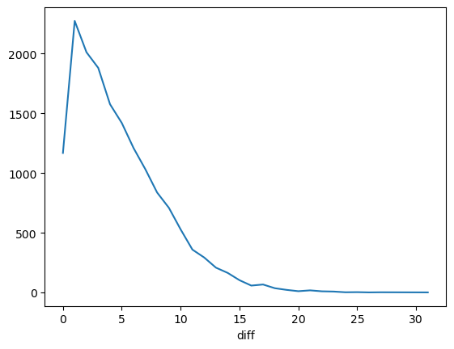

```python
(predictions["diff"].round().value_counts()).sort_index().plot()
```

```python
# from sklearn.metrics import accuracy_score
# accuracy_score(predictions["actual"].round(),predictions["prediction"].round())
# (predictions["diff"].round().value_counts()).sort_index().plot()
```

```python
#accuracy of the model
# (predictions["diff"].round().value_counts()).sort_index().sum() / predictions.shape[0] * 100
```

```python
# test = predictions["actual"] # ~ looks for all columns in the list except these columns
# pred = predictions["prediction"]
# test
```

```python
# pred
```

```python
from sklearn.metrics import mean_absolute_error, mean_squared_error, r2_score
import numpy as  np
actual = predictions['actual']
prediction=predictions['prediction']
# Assuming 'actual' contains actual values and 'prediction' contains predicted values
mae = mean_absolute_error(actual, prediction)
mse = mean_squared_error(actual, prediction)
rmse = np.sqrt(mse)
r2 = r2_score(actual, prediction)

print(f"Mean Absolute Error: {mae}")
print(f"Mean Squared Error: {mse}")
print(f"Root Mean Squared Error: {rmse}")
print(f"R-squared: {r2}")
```

```
Mean Absolute Error: 4.786248018944604
Mean Squared Error: 37.56933417066942
Root Mean Squared Error: 6.129382853980442
R-squared: 0.8741659251634186
```

```python
actual = Functional_Backtesting['actual_F']
prediction=Functional_Backtesting['prediction_F']
# Assuming 'actual' contains actual values and 'prediction' contains predicted values
mae_F = mean_absolute_error(actual, prediction)
mse_F = mean_squared_error(actual, prediction)
rmse_F = np.sqrt(mse)
r2_F = r2_score(actual, prediction)

print(f"Mean Absolute Error: {mae_F}")
print(f"Mean Squared Error: {mse_F}")
print(f"Root Mean Squared Error: {rmse_F}")
print(f"R-squared: {r2_F}")
```

```
Mean Absolute Error: 5.136267426300147
Mean Squared Error: 42.98640103633378
Root Mean Squared Error: 6.129382853980442
R-squared: 0.8561719748777098
```

```python
print(f"MAE with backtesting                  : {mae}\nMAE with functional backtesting       : {mae_F}")
print(f"\nMSE with backtesting                  : {mse}\nMSE with functinoal backtesting       : {mse_F}")
print(f"\nRMSE with backtesting                 : {rmse}\nRMSE with functional backtesting      : {rmse_F}")
print(f"\nR-squared with backtesting            : {r2}\nR-squared with functional backtesting : {r2_F}")
```

```
MAE with backtesting                  : 4.786248018944604
MAE with functional backtesting       : 5.136267426300147

MSE with backtesting                  : 37.56933417066942
MSE with functinoal backtesting       : 42.98640103633378

RMSE with backtesting                 : 6.129382853980442
RMSE with functional backtesting      : 6.129382853980442

R-squared with backtesting            : 0.8741659251634186
R-squared with functional backtesting : 0.8561719748777098
```

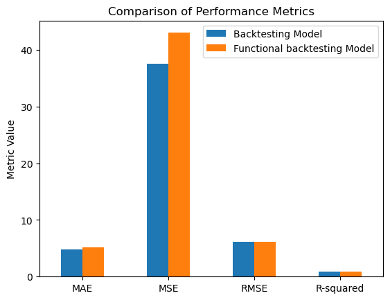

```python
import matplotlib.pyplot as plt

# Performance metrics for the first set of predictions
metrics = {'MAE': mae, 'MSE': mse, 'RMSE': rmse, 'R-squared': r2}

# Performance metrics for the second set of predictions
metrics_F = {'MAE': mae_F, 'MSE': mse_F, 'RMSE': rmse_F, 'R-squared': r2_F}

# Combine the metrics for easy plotting
combined_metrics = pd.DataFrame({'Backtesting Model': metrics, 'Functional backtesting Model': metrics_F})

# Plotting the bar chart
combined_metrics.plot(kind='bar', rot=0)
plt.title('Comparison of Performance Metrics')
plt.ylabel('Metric Value')
plt.show()
```

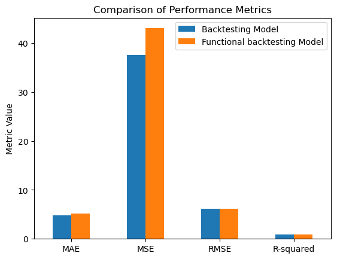

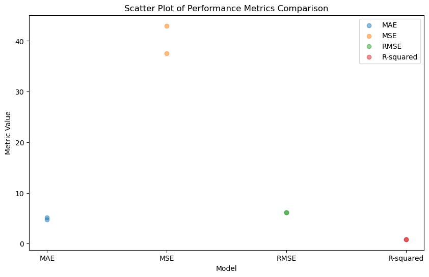

```python
import matplotlib.pyplot as plt
import seaborn as sns

# Performance metrics for the first set of predictions
metrics = {'MAE': mae, 'MSE': mse, 'RMSE': rmse, 'R-squared': r2}

# Performance metrics for the second set of predictions
metrics_F = {'MAE': mae_F, 'MSE': mse_F, 'RMSE': rmse_F, 'R-squared': r2_F}

# Combine the metrics for easy plotting
combined_metrics = pd.DataFrame({'Backtesting Model': metrics, 'Functional backtesting Model': metrics_F})

# Plotting the bar chart
combined_metrics.plot(kind='bar', rot=0)
plt.title('Comparison of Performance Metrics')
plt.ylabel('Metric Value')

# Scatter plot for comparison
plt.figure(figsize=(10, 6))
for metric in metrics.keys():
    plt.scatter(x=[metric] * 2, y=[metrics[metric], metrics_F[metric]], label=f'{metric}', alpha=0.5)

plt.title('Scatter Plot of Performance Metrics Comparison')
plt.xlabel('Model')
plt.ylabel('Metric Value')
plt.legend()
plt.show()
```